# P8105_hw4_mc4433

Manqi Cai

10/25/2017

# Problem 1

The project lead will load and tidy the data for this problem. The original data file includes data in “wide” format: the post-natal days on which developmental landmarks are reached are stored in columns called PD_outcome. The project lead will convert these data to “long” format, using reasonable variable names and values.

The collaborator will create a plot showing the distribution of post-natal days for each developmental landmark.

# Problem 2

The project lead will load and tidy the data for this problem. Combine the data in pols-month.csv and GDP.csv based on the date / month (use lubridate::floor_date to collase dates to the first day of the month).

The collaborator will create a plot showing the GDP value over time, including the party of the president in an informative aesthetic.

```r
pols_month_data <- read_csv("../data/fivethirtyeight_datasets/pols-month.csv", col_types = "ciiiiiiii") %>%
  clean_names() %>%
  mutate(mon = as.Date(mon),
         mon = lubridate::floor_date(mon, unit = "month")) %>%
  rename(date = mon)


gdp_data <- read_csv("../data/fivethirtyeight_datasets/GDP.csv") %>%
  clean_names() %>%
  mutate(date = lubridate::floor_date(date, unit = "month"))
combine_data <- inner_join(pols_month_data, gdp_data, by = "date") %>%
  mutate(president = ifelse(prez_dem == 1, "dem", "gop")) %>%
  select(- prez_gop, - prez_dem)
```

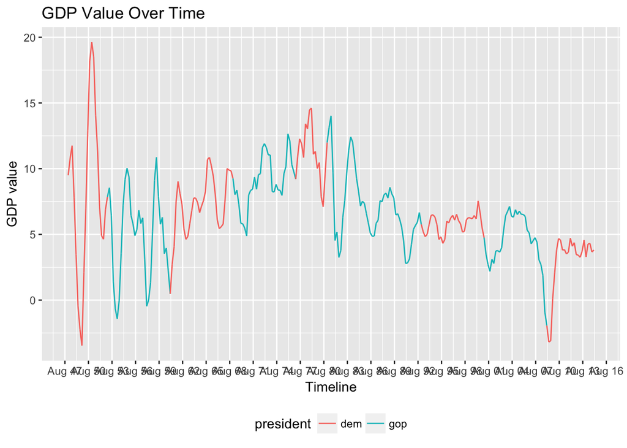

```r
combine_data %>%
  filter(value != ".") %>%
  mutate(value = as.numeric(value))%>%
  group_by(president) %>%
  ggplot(aes(x = date, y = value, color = president)) +
  geom_line(aes(group = 1)) +
  scale_x_date(date_labels = "%b %y", date_breaks = "36 month") +
  labs(title = "GDP Value Over Time", x = "Timeline", y = "GDP value") +
  theme(legend.position = "bottom")
```